# Single Cell RNA-seq Analysis - differentiating between cell clusters

Jessica Zhang

2022-11-03

## scRNA-seq Basics

Single cell RNA-sequencing is a an omic tool that enables the analysis of **transcriptomic information from individual cells**.

Here is a heavily simplifed step-by-step guide:

### 1. Prepare sample and sequence

- Isolate cells from tissue of interest. In this case we are looking at mouse hindlimb skeletal muscle tissues 14 days post-injury
- Each cell is **barcoded** with a specific oligo, so that all RNA sequences coming from the cell has the barcode sequence as a tail attached to it

### 2. Align all the reads to a reference genome using **CellRanger**.

### 3. Do a quality check of the RNA-seq and clean up the data using **Seurat**

- nFeature_RNA - the number of different RNA sequences detected in each cell
- nCount_RNA - the total number of RNA molecules detected in each cell
- **Filter data**: only include data that falls within the normal range of nFeature_RNA (make sure the cells are alive) and nCount_RNA (make sure only a single cell is sequenced)

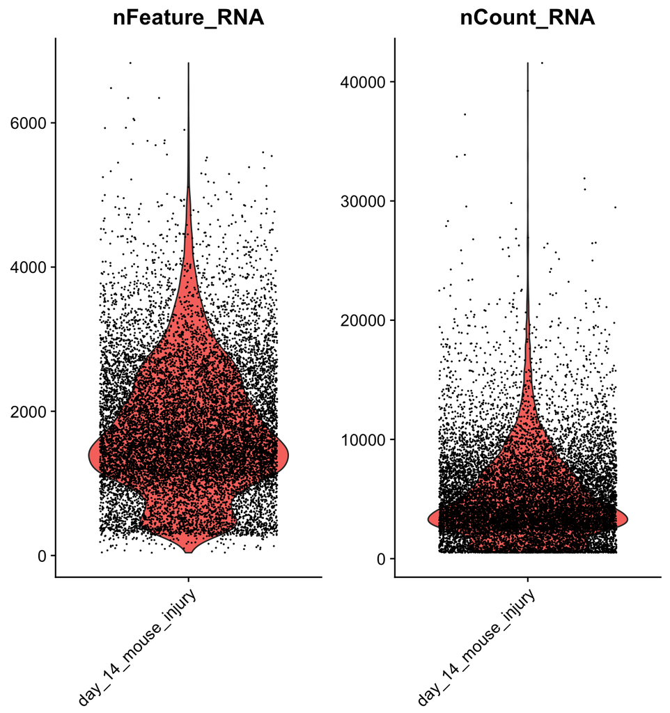

### 4. Perform some complex transformations to the data…

- scRNA-seq data is multi-dimensional - think of the expression level of each individual gene as an axis.
- Perform “dimensionality reduction” to visualise the data in a 2D plot  
  **PCA (principle component analysis)** -> **UMAP** -> **Feature plot**

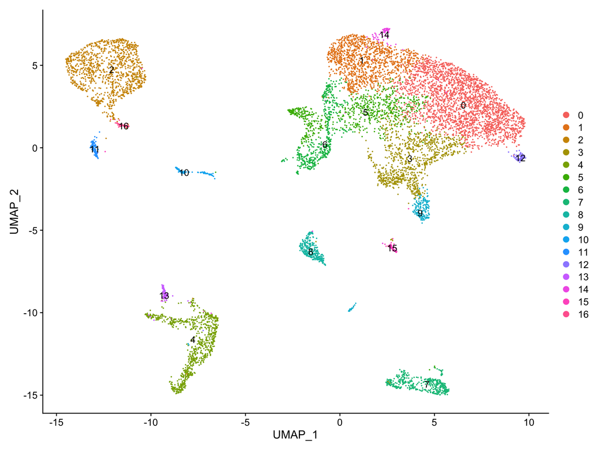

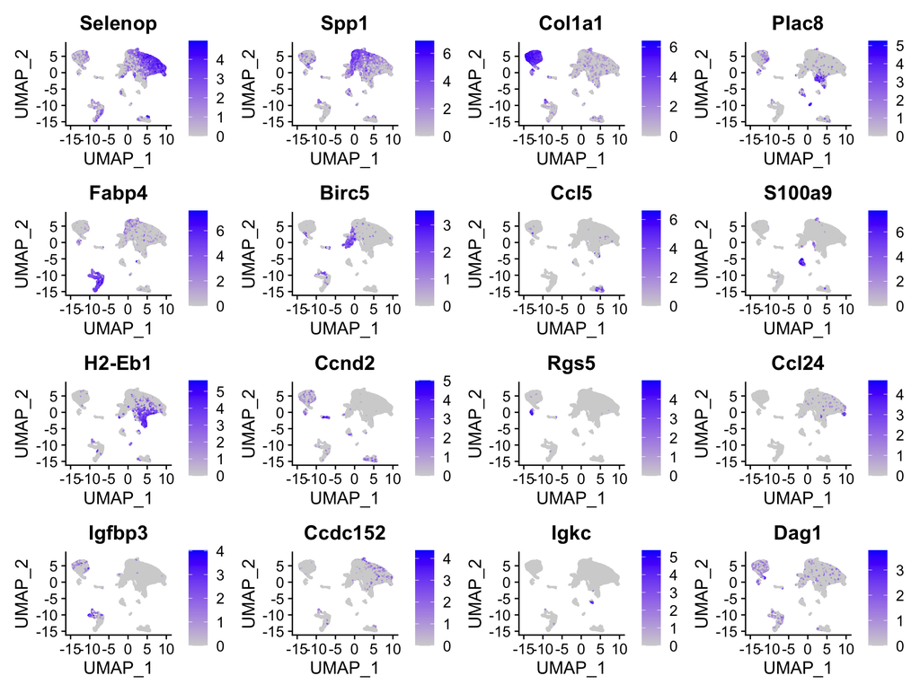

```
##         p_val avg_log2FC pct.1 pct.2 p_val_adj cluster    gene
## Ccl8        0   3.424369 0.512 0.119         0       0    Ccl8
## Selenop     0   2.687086 0.976 0.481         0       0 Selenop
## Apoe        0   2.352261 0.999 0.769         0       0    Apoe
## C1qa        0   2.282241 0.971 0.395         0       0    C1qa
## C1qb        0   2.197022 0.959 0.359         0       0    C1qb
## C1qc        0   2.176445 0.986 0.398         0       0    C1qc
## Ms4a7       0   1.848563 0.976 0.428         0       0   Ms4a7
## Pltp        0   1.753643 0.946 0.447         0       0    Pltp
## Mrc1        0   1.687957 0.736 0.225         0       0    Mrc1
## Itm2b       0   1.680919 0.998 0.899         0       0   Itm2b
```

### 5. Identify each cell cluster’s identity using known markers

- Use known databases and literatures

### Reference for methods:

- CellRanger: https://support.10xgenomics.com/single-cell-gene-expression/software/pipelines/latest/what-is-cell-ranger
- Seurat: https://satijalab.org/seurat/
- All data from @DiaoLab